# Project 1

Yuhan Xiao

2023-09-16

## Background

```r
library(here)
library(tidyverse)
library(dplyr)
library(gapminder)
library(paletteer)

# tests if a directory named "data" exists locally
if (!dir.exists(here("data"))) {
    dir.create(here("data"))
}

# saves data only once (not each time you knit a R Markdown)
if (!file.exists(here("data", "chocolate.RDS"))) {
    url_csv <- "https://raw.githubusercontent.com/rfordatascience/tidytuesday/master/data/2022/2022-01-18/chocolate.csv"
    chocolate <- readr::read_csv(url_csv)

    # save the file to RDS objects
    saveRDS(chocolate, file = here("data", "chocolate.RDS"))
}

# read the data locally
chocolate <- readRDS(here("data", "chocolate.RDS"))
as_tibble(chocolate)
```

```
## # A tibble: 2,530 × 10
##      ref company_manufacturer company_location review_date
##    <dbl> <chr>                <chr>                  <dbl>
##  1  2454 5150                 U.S.A.                  2019
##  2  2458 5150                 U.S.A.                  2019
##  3  2454 5150                 U.S.A.                  2019
##  4  2542 5150                 U.S.A.                  2021
##  5  2546 5150                 U.S.A.                  2021
##  6  2546 5150                 U.S.A.                  2021
##  7  2542 5150                 U.S.A.                  2021
##  8   797 A. Morin             France                  2012
##  9   797 A. Morin             France                  2012
## 10  1011 A. Morin             France                  2013
## # ℹ 2,520 more rows
## # ℹ 6 more variables: country_of_bean_origin <chr>,
## #   specific_bean_origin_or_bar_name <chr>, cocoa_percent <chr>,
## #   ingredients <chr>, most_memorable_characteristics <chr>, rating <dbl>
```

```r
# take a glimpse of the data
glimpse(chocolate)
```

```
## Rows: 2,530
## Columns: 10
## $ ref                              <dbl> 2454, 2458, 2454, 2542, 2546, 2546, 2…
## $ company_manufacturer             <chr> "5150", "5150", "5150", "5150", "5150…
## $ company_location                 <chr> "U.S.A.", "U.S.A.", "U.S.A.", "U.S.A.…
## $ review_date                      <dbl> 2019, 2019, 2019, 2021, 2021, 2021, 2…
## $ country_of_bean_origin           <chr> "Tanzania", "Dominican Republic", "Ma…
## $ specific_bean_origin_or_bar_name <chr> "Kokoa Kamili, batch 1", "Zorzal, bat…
## $ cocoa_percent                    <chr> "76%", "76%", "76%", "68%", "72%", "8…
## $ ingredients                      <chr> "3- B,S,C", "3- B,S,C", "3- B,S,C", "…
## $ most_memorable_characteristics   <chr> "rich cocoa, fatty, bready", "cocoa, …
## $ rating                           <dbl> 3.25, 3.50, 3.75, 3.00, 3.00, 3.25, 3…
```

## Part 1: Explore data

1. Make a histogram of the rating scores to visualize the overall distribution of scores. Change the number of bins from the default to 10, 15, 20, and 25. Pick on the one that you think looks the best. Explain what the difference is when you change the number of bins and explain why you picked the one you did.

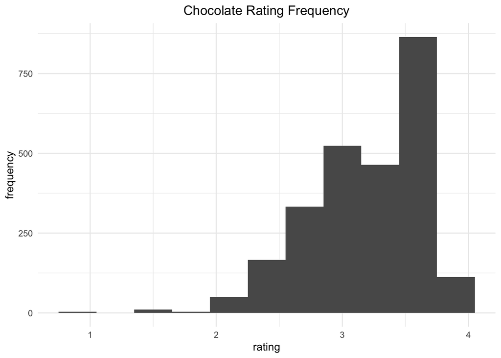

```r
ggplot(chocolate, aes(x=rating)) +
  geom_histogram(bins=10, binwidth = 3/10) +
  labs(x= "rating", y="frequency", title ="Chocolate Rating Frequency") +
  theme_minimal() +
  theme(plot.title = element_text(hjust = 0.5))
```

2. Consider the countries where the beans originated from. How many reviews come from each country of bean origin?

```r
chocolate %>%
  select(rating,country_of_bean_origin) %>%
  count(country_of_bean_origin)
```

```
## # A tibble: 62 × 2
##    country_of_bean_origin     n
##    <chr>                  <int>
##  1 Australia                  3
##  2 Belize                    76
##  3 Blend                    156
##  4 Bolivia                   80
##  5 Brazil                    78
##  6 Burma                      1
##  7 Cameroon                   3
##  8 China                      1
##  9 Colombia                  79
## 10 Congo                     11
## # ℹ 52 more rows
```

3. What is average rating scores from reviews of chocolate bars that have Ecuador as country_of_bean_origin in this dataset? For this same set of reviews, also calculate (1) the total number of reviews and (2) the standard deviation of the rating scores. Your answer should be a new data frame with these three summary statistics in three columns. Label the name of these columns mean, sd, and total.

```r
summary_data <- chocolate %>%
  select(rating,country_of_bean_origin) %>%
  filter(country_of_bean_origin == "Ecuador") %>%
  summarise(
    mean = mean(rating),
    sd = sd(rating),
    total = n()
  )
as.data.frame(summary_data)
```

```
##       mean        sd total
## 1 3.164384 0.5122678   219
```

4. Which company (name) makes the best chocolate (or has the highest ratings on average) with beans from Ecuador?

```r
chocolate %>%
  select(rating,country_of_bean_origin,company_manufacturer) %>%
  filter(country_of_bean_origin == "Ecuador") %>%
  group_by(company_manufacturer) %>%
  summarise(
    mean = mean(rating),
  ) %>%
  arrange(desc(mean)) %>%
  head(5)
```

```
## # A tibble: 5 × 2
##   company_manufacturer    mean
##   <chr>                  <dbl>
## 1 Amano                      4
## 2 Benoit Nihant              4
## 3 Beschle (Felchlin)         4
## 4 Durci                      4
## 5 Smooth Chocolator, The     4
```

5. Calculate the average rating across all country of origins for beans. Which top 3 countries (for bean origin) have the highest ratings on average?

```r
chocolate %>%
  select(rating,country_of_bean_origin) %>%
  group_by(country_of_bean_origin) %>%
  summarise(
    mean = mean(rating),
  ) %>%
  arrange(desc(mean)) %>%
  head(3)
```

```
## # A tibble: 3 × 2
##   country_of_bean_origin  mean
##   <chr>                  <dbl>
## 1 Tobago                  3.62
## 2 China                   3.5
## 3 Sao Tome & Principe     3.5
```

6. Following up on the previous problem, now remove any countries of bean origins that have less than 10 chocolate bar reviews. Now, which top 3 countries have the highest ratings on average?

```r
chocolate %>%
  select(rating,country_of_bean_origin) %>%
  group_by(country_of_bean_origin) %>%
  summarise(
    mean = mean(rating),
    total = n()
  ) %>%
  filter(total >= 10) %>%
  arrange(desc(mean)) %>%
  head(3)
```

```
## # A tibble: 3 × 3
##   country_of_bean_origin  mean total
##   <chr>                  <dbl> <int>
## 1 Solomon Islands         3.45    10
## 2 Congo                   3.32    11
## 3 Cuba                    3.29    12
```

7. On average, which category of chocolate percentage is most highly rated? Do these countries mostly agree or are there disagreements?

```r
# first step: Identify the countries of bean origin with at least 50 reviews. Remove reviews from countries are not in this list.
countries_with_enough_reviews <- chocolate %>%
  select(country_of_bean_origin) %>%
  group_by(country_of_bean_origin) %>%
  summarise(
    total = n()
  ) %>%
  filter(total >= 50) %>%
  pull(country_of_bean_origin)

# second step: Using the variable describing the chocolate percentage for each review, create a new column that groups chocolate percentages into one of four groups: (i) <60%, (ii) >=60 to <70%, (iii) >=70 to <90%, and (iii) >=90% (Hint check out the substr() function in base R and the case_when() function from dplyr – see example below).
summary_percent_cocoa <- chocolate %>%
  select(country_of_bean_origin, cocoa_percent, rating) %>%
  filter(country_of_bean_origin %in% countries_with_enough_reviews) %>%
  mutate(numeric_cocoa_percent = as.numeric(sub("%", "", cocoa_percent))) %>%
  mutate(cocoa_percent_category = case_when(
    numeric_cocoa_percent < 60 ~ "<60%",
    60 <= numeric_cocoa_percent &  numeric_cocoa_percent < 70 ~ ">=60 to <70%",
    70 <= numeric_cocoa_percent & numeric_cocoa_percent < 90 ~ ">=70 to <90%",
    numeric_cocoa_percent >= 90 ~ ">=90%"
  )) %>%
  mutate(cocoa_percent_category = as.factor(cocoa_percent_category))

# third step: Using the new column described in #2, re-order the factor levels (if needed) to be starting with the smallest percentage group and increasing to the largest percentage group (Hint check out the fct_relevel() function from forcats).
summary_percent_cocoa %>%
  select(country_of_bean_origin, rating, cocoa_percent_category) %>%
  arrange(cocoa_percent_category) %>%
  group_by(cocoa_percent_category) %>%
  summarise(mean=mean(rating))
```

```
## # A tibble: 4 × 2
##   cocoa_percent_category  mean
##   <fct>                  <dbl>
## 1 <60%                    2.96
## 2 >=60 to <70%            3.25
## 3 >=70 to <90%            3.22
## 4 >=90%                   2.49
```

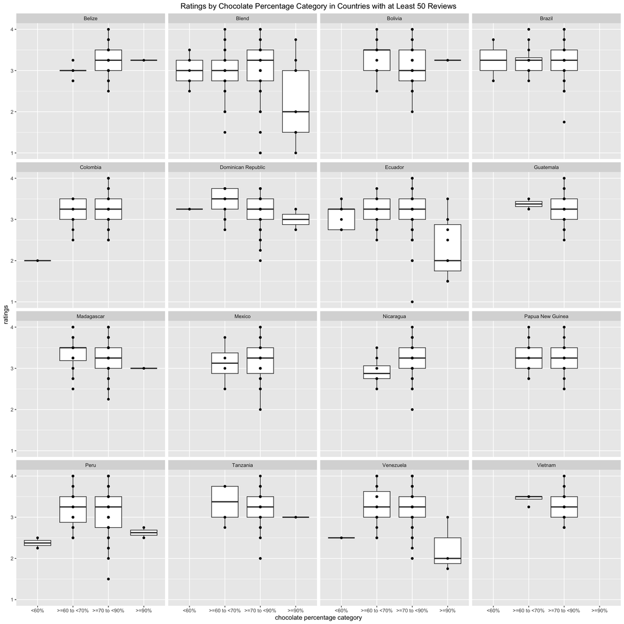

```r
# fourth step: For each country, make a set of four side-by-side boxplots plotting the groups on the x-axis and the ratings on the y-axis. These plots should be faceted by country.
ggplot(summary_percent_cocoa, aes(x = cocoa_percent_category , y = rating)) +
  geom_boxplot() +
  geom_point() +
  facet_wrap(~country_of_bean_origin,nrow=4, scales="fixed") +
  labs(x = "chocolate percentage category", y = "ratings", title = "Ratings by Chocolate Percentage Category in Countries with at Least 50 Reviews") +
  theme(
    plot.title = element_text(hjust = 0.5)  # Center the title
  )
```

## Part 2: Join two datasets together

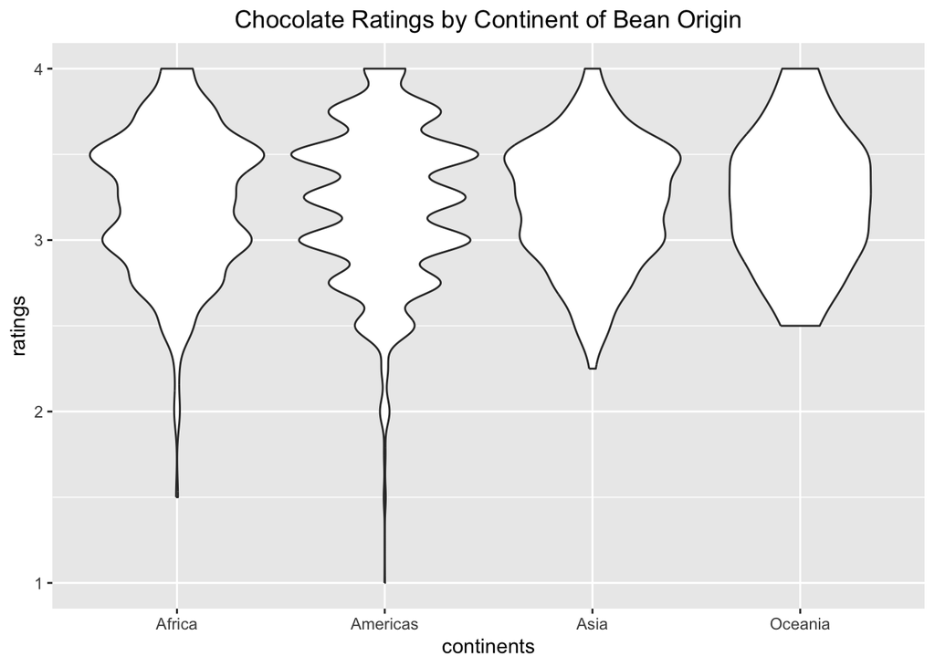

```r
# get continent info from gapminder
continent_data <- as_tibble(gapminder) %>%
  select(country, continent) %>%
  rename("country_of_bean_origin" = "country") %>%
  unique()

# join continent info with chocolate info
chocolate_w_continent <- chocolate %>%
  left_join(continent_data, by = "country_of_bean_origin")

# find countries with enough reviews
countries_with_enough_reviews <- chocolate_w_continent %>%
  select(country_of_bean_origin) %>%
  group_by(country_of_bean_origin) %>%
  summarise(
    total = n()
  ) %>%
  filter(total >= 10) %>%
  pull(country_of_bean_origin)

# filter out countries with enough reviews and remove countries named Blend
chocolate_w_continent_filtered <- chocolate_w_continent %>%
  select(country_of_bean_origin, continent, rating) %>%
  filter(as.character(country_of_bean_origin) %in% countries_with_enough_reviews) %>%
  filter(toupper(country_of_bean_origin) != "BLEND") %>%
  arrange(desc(rating))

# find countries of bean origin with missing continent
country_wo_continent <- chocolate_w_continent_filtered %>%
  filter(is.na(continent)) %>%
  distinct(country_of_bean_origin)

# assign countries with missing continent to a continent manually
chocolate_w_continent_filtered <- chocolate_w_continent_filtered %>%
  mutate(continent=ifelse(is.na(continent), case_when(
    country_of_bean_origin == "Fiji" ~ "Oceania",
    country_of_bean_origin == "Papua New Guinea" ~ "Oceania",
    country_of_bean_origin == "Sao Tome" ~ "Africa",
    country_of_bean_origin == "Vanuatu" ~ "Oceania",
    country_of_bean_origin == "Trinidad" ~ "Americas",
    country_of_bean_origin == "Belize" ~ "Americas",
    country_of_bean_origin == "Grenada" ~ "Americas",
    country_of_bean_origin == "Solomon Islands" ~ "Oceania",
    country_of_bean_origin == "St. Lucia" ~ "Americas",
    country_of_bean_origin == "Congo" ~ "Africa",
    country_of_bean_origin == "U.S.A." ~ "Americas"
  ), as.character(continent)))

# Make a set of violin plots with ratings on the y-axis and continents on the x-axis.
ggplot(chocolate_w_continent_filtered, aes(x = continent, y = rating)) +
  geom_violin(trim=TRUE) +
  labs(x = "continents", y = "ratings", title = "Chocolate Ratings by Continent of Bean Origin") +
  theme(
    plot.title = element_text(hjust = 0.5)  # Center the title
  )
```

## Part 3: Convert wide data into long data

```r
# first step: Create a new set of columns titled beans, sugar, cocoa_butter, vanilla, lecithin, and salt that contain a 1 or 0 representing whether or not that review for the chocolate bar contained that ingredient (1) or not (0)

# second step: Create a new set of columns titled char_cocoa, char_sweet, char_nutty, char_creamy, char_roasty, char_earthy that contain a 1 or 0 representing whether or not that the most memorable characteristic for the chocolate bar had that word (1) or not (0). For example, if the word “sweet” appears in the most_memorable_characteristics, then record a 1, otherwise a 0 for that review in the char_sweet column

# select necessary variables and store into a new data frame
chocolate_feature <- chocolate %>%
  select(ingredients, most_memorable_characteristics, rating, review_date)

# create vectors to store ingredients and characteristics of interest
ingredients_names <- c("beans", "sugar", "cocoa_butter", "vanilla", "lecithin", "salt")
ingredients_abbr <- c("B", "S", "C", "V", "L", "Sa")

char_names <- c("char_cocoa", "char_sweet", "char_nutty", "char_creamy", "char_roasty", "char_earthy")
char_abbr <- c("cocoa", "sweet", "nutty", "creamy", "roasty", "earthy")

# create lists to store ingredients and characteristics vectors
col_names <- list(ingredients_names, char_names)
col_abbr <- list(ingredients_abbr, char_abbr)
col_variables <- c("ingredients", "most_memorable_characteristics")

for (n in 1:length(col_names)) {
  # generate error message if lengths don't match
  if (length(col_names[[n]]) != length(col_abbr[[n]])) {
    stop("vector_names has a different length than vector_abbr")
  }

  # add new columns for indicating if an ingredient or characteristic exists
  for (i in 1:length(col_names[[n]])) {
    chocolate_feature <- chocolate_feature %>%
      mutate(!!col_names[[n]][i] := case_when(
        str_detect(!!as.name(col_variables[n]), as.character(col_abbr[[n]][i])) == TRUE ~ 1,
        TRUE ~ 0
      ))
  }
}
```

```r
# third step: For each year (i.e. review_date), calculate the mean value in each new column you created across all reviews for that year. (Hint: If all has gone well thus far, you should have a dataset with 16 rows and 13 columns)

# create a base data frame from chocolate with distinct review_date
choc_feature_avg <- chocolate %>%
  distinct(review_date) %>%
  arrange(review_date)

# calculate the average for each column for each ingredient and characteristic
for (n in 1:length(col_names)) {
  for (i in 1:length(col_names[[n]])) {
    choc_feature_avg_subset <- chocolate_feature %>%
      group_by(review_date) %>%
      summarize(!!col_names[[n]][i] := mean(!!sym(col_names[[n]][i])))
    choc_feature_avg <- choc_feature_avg %>%
      left_join(choc_feature_avg_subset, by = join_by(review_date))
  }
}

choc_feature_avg
```

```
## # A tibble: 16 × 13
##    review_date beans sugar cocoa_butter vanilla lecithin    salt char_cocoa
##          <dbl> <dbl> <dbl>        <dbl>   <dbl>    <dbl>   <dbl>      <dbl>
##  1        2006 0.968 0.968        0.903  0.694    0.694  0           0.210
##  2        2007 0.945 0.945        0.767  0.548    0.384  0           0.342
##  3        2008 0.913 0.902        0.75   0.359    0.511  0           0.109
##  4        2009 0.919 0.919        0.772  0.325    0.341  0           0.146
##  5        2010 0.855 0.855        0.709  0.227    0.391  0.00909     0.218
##  6        2011 0.939 0.939        0.693  0.160    0.160  0.0491      0.172
##  7        2012 0.928 0.928        0.675  0.186    0.124  0.0722      0.0876
##  8        2013 0.967 0.956        0.776  0.208    0.295  0.0164      0.175
##  9        2014 0.984 0.984        0.644  0.0688   0.121  0.0324      0.0607
## 10        2015 0.986 0.979        0.546  0.0599   0.120  0           0.127
## 11        2016 0.982 0.977        0.594  0.0507   0.106  0.00922     0.0922
## 12        2017 0.981 0.981        0.562  0.0286   0.133  0.00952     0.133
## 13        2018 0.987 0.987        0.596  0.0614   0.132  0           0.180
## 14        2019 1     1            0.679  0.0259   0.202  0           0.259
## 15        2020 1     1            0.568  0.0370   0.0247 0           0.284
## 16        2021 1     0.994        0.646  0.0114   0.0800 0           0.297
## # ℹ 5 more variables: char_sweet <dbl>, char_nutty <dbl>, char_creamy <dbl>,
## #   char_roasty <dbl>, char_earthy <dbl>
```

```r
# fourth step: Convert this wide dataset into a long dataset with a new feature and mean_score column.
choc_feature_avg_long <- choc_feature_avg %>%
  pivot_longer(-review_date, names_to = "feature", values_to = "mean_score") %>%
  mutate(feature=factor(feature), mean_score=as.numeric(mean_score))
choc_feature_avg_long
```

```
## # A tibble: 192 × 3
##    review_date feature      mean_score
##          <dbl> <fct>             <dbl>
##  1        2006 beans            0.968
##  2        2006 sugar            0.968
##  3        2006 cocoa_butter     0.903
##  4        2006 vanilla          0.694
##  5        2006 lecithin         0.694
##  6        2006 salt             0
##  7        2006 char_cocoa       0.210
##  8        2006 char_sweet       0.161
##  9        2006 char_nutty       0.0323
## 10        2006 char_creamy      0.242
## # ℹ 182 more rows
```

# Part 4: Data visualization

```r
paletteer_d("ggprism::colors", 12)
```

```
## <colors>
## #0000FFFF #FF0000FF #00C000FF #AD07E3FF #FF8000FF #000000FF #94641FFF #000080FF #610051FF #A00000FF #056943FF #F2B77CFF
```

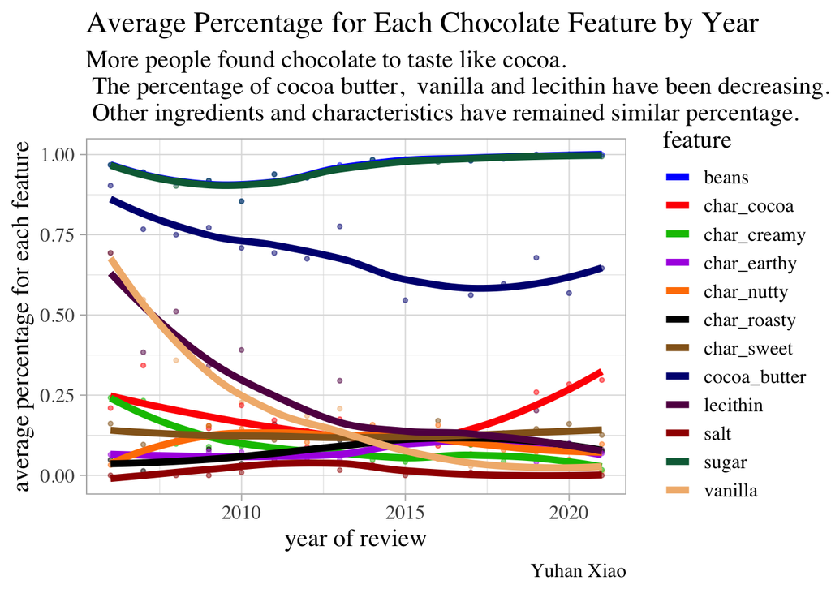

```r
ggplot(choc_feature_avg_long, aes(x = review_date, y = mean_score, color=feature)) +
  geom_point(size=1, alpha=1/2) +
  geom_smooth(linewidth = 2, se=FALSE) +
  labs(x = "year of review", y = "average percentage for each feature", title = "Average Percentage for Each Chocolate Feature by Year", subtitle = "More people found chocolate to taste like cocoa. \n The percentage of cocoa butter,  vanilla and lecithin have been decreasing. \n Other ingredients and characteristics have remained similar percentage.", caption = "Yuhan Xiao") +
  theme_light(base_family = "Times", base_size = 15) +
  theme(legend.position="right")+
  scale_color_manual(values=paletteer_d("ggprism::colors", 12))
```

# Part 5: Make the worst plot you can!

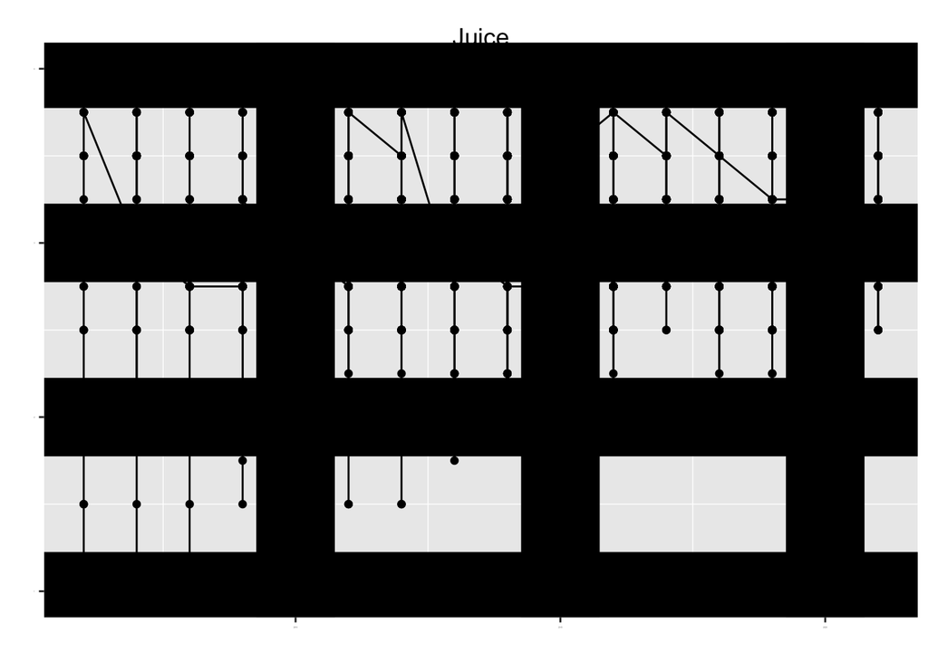

```r
# 7 ways of customization to make this plot awful
# - use geom_point() which does not make much sense
# - use geom_line() which also does not make much sense
# - remove axis labels
# - irrelevant title
# - set panel.grid.major to be black so that points are not visible
# - set axis text size to be very small
# - set title position to hide under the figure

choc_worst_plot <- chocolate %>%
  ggplot(aes(x=review_date, y=rating)) +
  geom_point() +
  geom_line() +
  labs(x="",y="", title="Juice") +
  theme(panel.grid.major = element_line(color = "black", linewidth = 20),  # major gridlines
    axis.text = element_text(size = 1), # axis text
    plot.title = element_text(hjust = 0.5, vjust = -2.5)) # title position
choc_worst_plot
```

# Part 6: Make my plot a better plot!

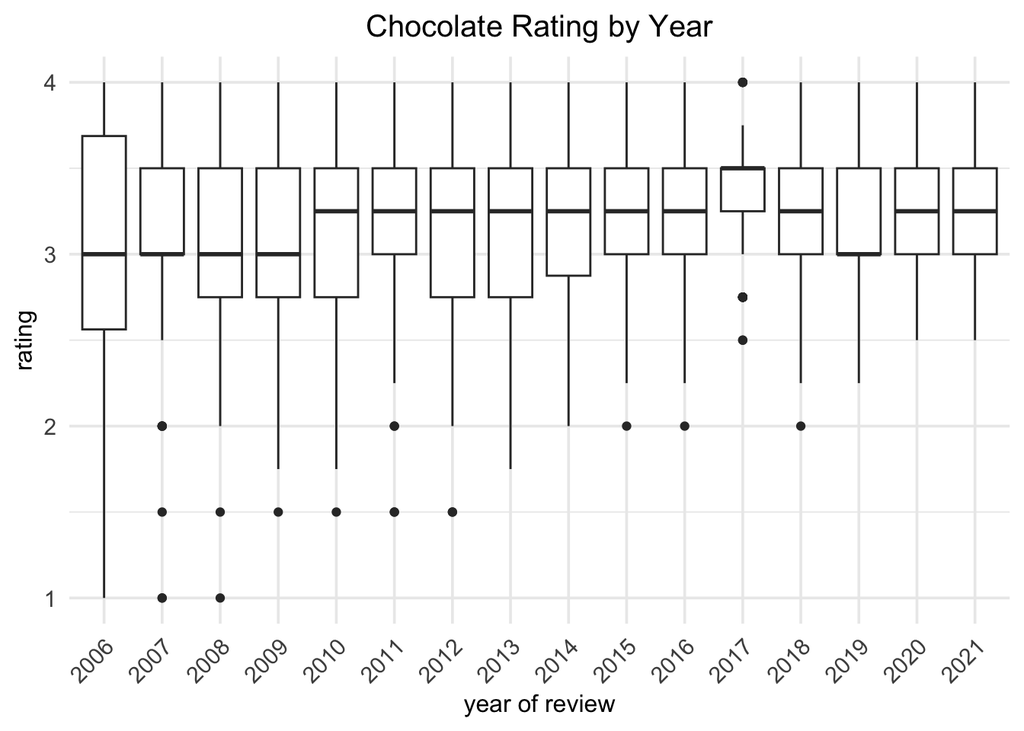

```r
# 7 ways to make this plot better
# - remove legend and fill color
# - change violin plot to a box plot
# - update axis labels to be more informative
# - add a title
# - add a minimal theme
# - position the title in the center and make it bigger
# - rotate x axis label and adjust its height
# - make x and y axis titles bigger
chocolate %>%
    ggplot(aes(x = as.factor(review_date), y = rating)) +
    geom_boxplot() +
    labs(x="year of review",y="rating", title="Chocolate Rating by Year") +
    theme_minimal(base_size=14) +
    theme(plot.title = element_text(hjust = 0.5, vjust = 1, size=15),
          axis.text.x = element_text(angle = 45, hjust = 1),
          axis.title = element_text(size=12)
    )
```